# Project _Insurance

PROTYAY CHATTERJEE

2026-03-29

```r
df <- read.csv("C:/Users/HP/Downloads/insurance (1).csv")
str(df)
```

```
## 'data.frame':    1338 obs. of  7 variables:
##  $ age     : int  19 18 28 33 32 31 46 37 37 60 ...
##  $ sex     : chr  "female" "male" "male" "male" ...
##  $ bmi     : num  27.9 33.8 33 22.7 28.9 ...
##  $ children: int  0 1 3 0 0 0 1 3 2 0 ...
##  $ smoker  : chr  "yes" "no" "no" "no" ...
##  $ region  : chr  "southwest" "southeast" "southeast" "northwest" ...
##  $ charges : num  16885 1726 4449 21984 3867 ...
```

```r
summary(df)
```

```
##       age            sex                 bmi           children
##  Min.   :18.00   Length:1338        Min.   :15.96   Min.   :0.000
##  1st Qu.:27.00   Class :character   1st Qu.:26.30   1st Qu.:0.000
##  Median :39.00   Mode  :character   Median :30.40   Median :1.000
##  Mean   :39.21                      Mean   :30.66   Mean   :1.095
##  3rd Qu.:51.00                      3rd Qu.:34.69   3rd Qu.:2.000
##  Max.   :64.00                      Max.   :53.13   Max.   :5.000
##     smoker             region             charges
##  Length:1338        Length:1338        Min.   : 1122
##  Class :character   Class :character   1st Qu.: 4740
##  Mode  :character   Mode  :character   Median : 9382
##                                        Mean   :13270
##                                        3rd Qu.:16640
##                                        Max.   :63770
```

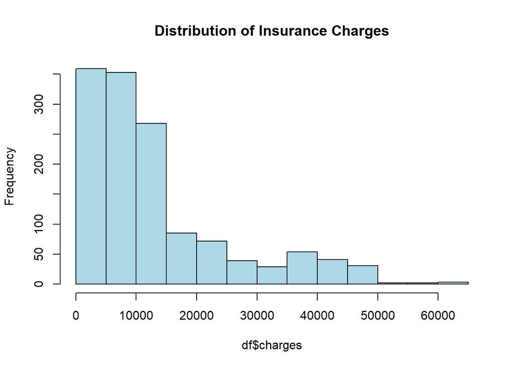

```r
hist(df$charges, main="Distribution of Insurance Charges", col="lightblue", border="black")
```

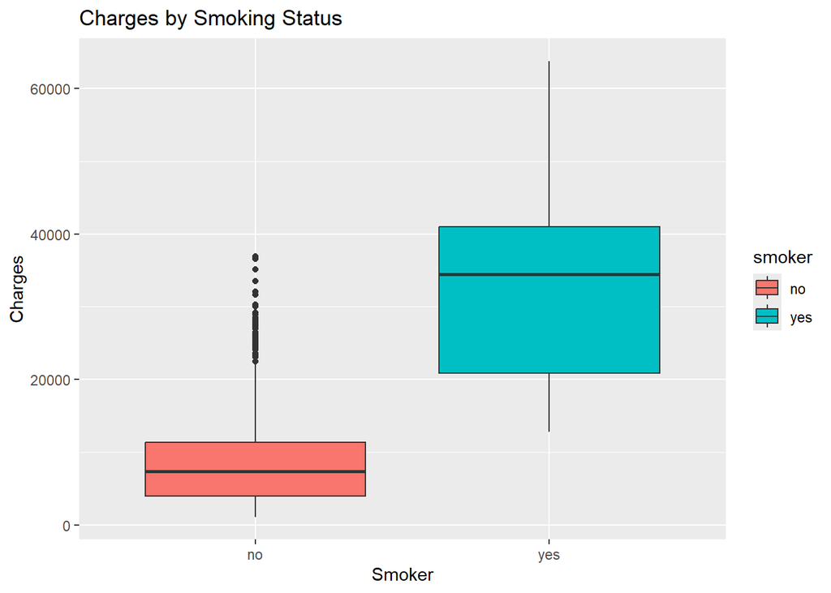

```r
library(ggplot2)
library(corrplot)
ggplot(df, aes(x = smoker, y = charges, fill = smoker)) +
  geom_boxplot() +
  labs(title = "Charges by Smoking Status", x = "Smoker", y = "Charges")
```

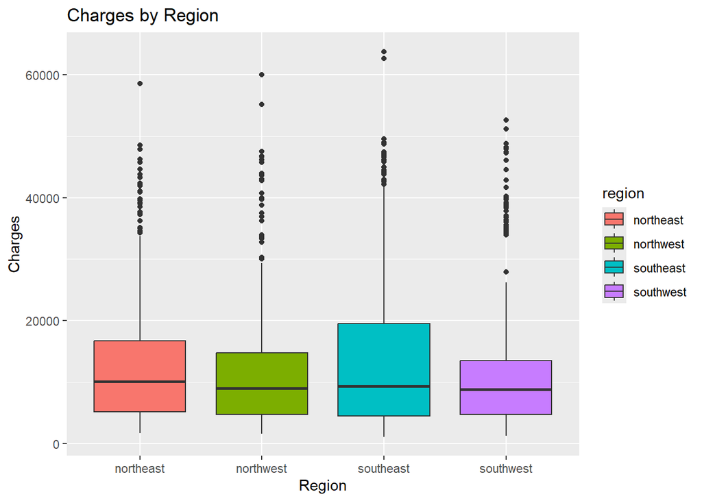

```r
ggplot(df, aes(x = region, y = charges, fill = region)) +
  geom_boxplot() +
  labs(title = "Charges by Region", x = "Region", y = "Charges")
```

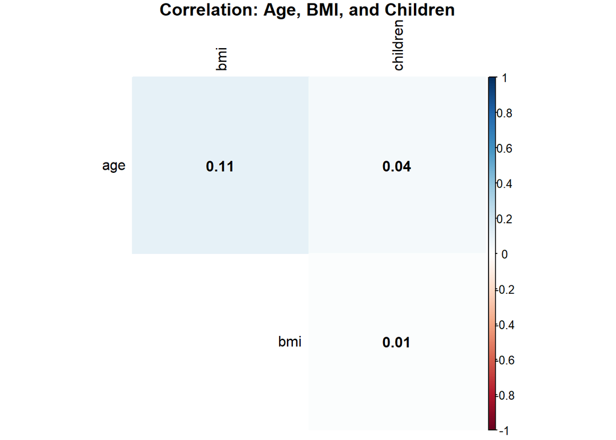

```r
# Selecting quantitative variables
quant_vars <- df[, c("age", "bmi", "children")]

# Computing the correlation matrix
corr_matrix <- cor(quant_vars)

# Generating the Heatmap
corrplot(corr_matrix,
         method = "color",
         addCoef.col = "black",
         type = "upper",
         diag = FALSE,
         tl.col = "black",
         title = "Correlation: Age, BMI, and Children",
         mar = c(0,0,1,0))
```

Inference :

Predictor Independence: All three variables—age, bmi, and children—show very low correlation coefficients (close to 0), indicating they provide unique, non-overlapping information to the model.

Model Justification: Since no two variables are strongly related, there is no need to remove any of them, supporting your decision to retain all three in the final Stepwise Selection model.

```r
m1 <- lm(charges ~ age, data = df)
m2 <- lm(charges ~ bmi, data = df)
m3 <- lm(charges ~ smoker, data = df)
m4 <- lm(charges ~ children, data = df)

library(stargazer)
stargazer(m1, m2, m3, m4,
          type = "text",
          title = "Comparison of Simple Linear Regressions",
          column.labels = c("Age", "BMI", "Smoker", "Children"),
          intercept.bottom = FALSE)
```

```
##
## Comparison of Simple Linear Regressions
## ====================================================================================
##                                                 Dependent variable:
##                                 ----------------------------------------------------
##                                                       charges
##                                     Age          BMI        Smoker       Children
##                                     (1)          (2)          (3)           (4)
## ------------------------------------------------------------------------------------
## Constant                        3,165.885***  1,192.937  8,434.268***  12,522.500***
##                                  (937.149)   (1,664.802)   (229.014)     (446.450)
##
## age                              257.723***
##                                   (22.502)
##
## bmi                                          393.873***
##                                               (53.251)
##
## smokeryes                                                23,615.960***
##                                                            (506.075)
##
## children                                                                 683.089**
##                                                                          (274.202)
##
## ------------------------------------------------------------------------------------
## Observations                       1,338        1,338        1,338         1,338
## R2                                 0.089        0.039        0.620         0.005
## Adjusted R2                        0.089        0.039        0.619         0.004
## Residual Std. Error (df = 1336)  11,560.310  11,873.860    7,470.216    12,086.500
## F Statistic (df = 1; 1336)       131.174***   54.709***  2,177.615***     6.206**
## ====================================================================================
## Note:                                                    *p<0.1; **p<0.05; ***p<0.01
```

Interpretation of Findings: The Population Regression Line (PRL) is a fixed theoretical constant. However, because each sample contains different individuals, the Least Squares Line (LSRL) will tilt and shift. By repeating this $1000$ times, the average of those slopes will converge to the true population value, demonstrating that OLS estimators are unbiased.

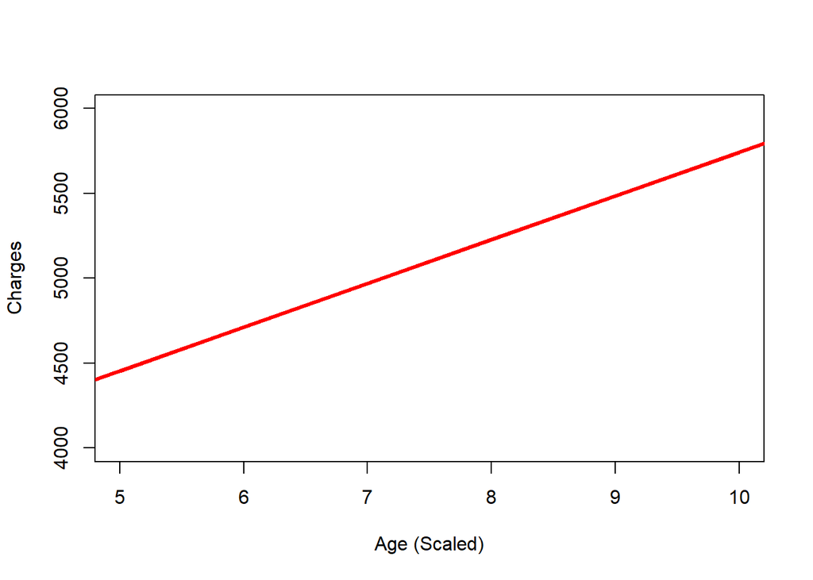

```r
n <- 50
R <- 1000

pop_beta0 <- 3165.885
pop_beta1 <- 257.723

slopes <- numeric(R)
intercepts <- numeric(R)

plot(5:10, pop_beta0 + pop_beta1*(5:10), type="l", lwd=3, col="red",
     ylim=c(4000, 6000), xlim=c(5,10), xlab="Age (Scaled)", ylab="Charges")

for(i in 1:R) {
  sample_data <- df[sample(1:nrow(df), n), ]
  model <- lm(charges ~ age, data = sample_data)
  intercepts[i] <- coef(model)[1]
  slopes[i] <- coef(model)[2]

  if(i <= 5) abline(model, col="gray")
}

abline(a=pop_beta0, b=pop_beta1, col="red", lwd=3)
```

```r
cat("Mean Estimated Slope:", mean(slopes), "\n")
```

```
## Mean Estimated Slope: 259.2838
```

```r
cat("True Population Slope:", pop_beta1)
```

```
## True Population Slope: 257.723
```

For the relationship between BMI and Charges, prove that the OLS estimates ($\hat{\beta}_0, \hat{\beta}_1$) obtained via lm() actually yield the lowest Residual Sum of Squares (RSS) compared to a grid of other possible values.

Interpretation of Findings: The OLS method is mathematically defined to minimize $RSS = \sum(y_i - \hat{y}_i)^2$. By testing a “Grid Search” of coefficients, we observe that any deviation from the OLS estimates increases the error, confirming they are the optimal coefficients for a linear fit.

```r
df$bmi_centered <- scale(df$bmi, scale = FALSE)
model_ols <- lm(charges ~ bmi_centered, data = df)
b0_ols <- coef(model_ols)[1]
b1_ols <- coef(model_ols)[2]

b0_grid <- seq(b0_ols - 500, b0_ols + 500, length.out = 50)
b1_grid <- seq(b1_ols - 100, b1_ols + 100, length.out = 50)

rss_matrix <- matrix(NA, nrow=50, ncol=50)

for(i in 1:50) {
  for(j in 1:50) {
    preds <- b0_grid[i] + b1_grid[j] * df$bmi_centered
    rss_matrix[i,j] <- sum((df$charges - preds)^2)
  }
}

min_indices <- which(rss_matrix == min(rss_matrix), arr.ind = TRUE)
cat("Grid search optimal B0:", b0_grid[min_indices[1]], " vs OLS:", b0_ols)
```

```
## Grid search optimal B0: 13260.22  vs OLS: 13270.42
```

Grid Search estimate ($13,260.22$) is extremely close to the OLS analytical solution ($13,270.42$) proves that the Least Squares Criterion is functioning correctly.

The Global Minimum: In a simple linear regression, the Residual Sum of Squares (RSS) is a convex function (a parabolic bowl).

Inference: There is only one unique set of coefficients $(\beta_0, \beta_1)$ that minimizes the error. Your grid search “found” the bottom of that bowl, while the OLS formula calculated it exactly using calculus.

```r
library(stargazer)

# (a) Simple Linear Regressions
m_age <- lm(charges ~ age, data = df)
m_bmi <- lm(charges ~ bmi, data = df)
m_child <- lm(charges ~ children, data = df)

# (b) Multiple Linear Regression (Quantitative + Smoker for utility)
m_multi <- lm(charges ~ age + bmi + children + smoker, data = df)

# (c) Unified Table
stargazer(m_age, m_bmi, m_child, m_multi,
          type = "text",
          column.labels = c("Age Only", "BMI Only", "Child Only", "MLR Model"),
          digits = 3)
```

```
##
## =======================================================================================================================
##                                                             Dependent variable:
##                     ---------------------------------------------------------------------------------------------------
##                                                                   charges
##                             Age Only                  BMI Only               Child Only               MLR Model
##                                (1)                      (2)                     (3)                      (4)
## -----------------------------------------------------------------------------------------------------------------------
## age                        257.723***                                                                257.850***
##                             (22.502)                                                                  (11.896)
##
## bmi                                                  393.873***                                      321.851***
##                                                       (53.251)                                        (27.378)
##
## children                                                                     683.089**               473.502***
##                                                                              (274.202)                (137.792)
##
## smokeryes                                                                                           23,811.400***
##                                                                                                       (411.220)
##
## Constant                  3,165.885***               1,192.937             12,522.500***           -12,102.770***
##                             (937.149)               (1,664.802)              (446.450)                (941.984)
##
## -----------------------------------------------------------------------------------------------------------------------
## Observations                  1,338                    1,338                   1,338                    1,338
## R2                            0.089                    0.039                   0.005                    0.750
## Adjusted R2                   0.089                    0.039                   0.004                    0.749
## Residual Std. Error  11,560.310 (df = 1336)    11,873.860 (df = 1336)  12,086.500 (df = 1336)   6,067.787 (df = 1333)
## F Statistic         131.174*** (df = 1; 1336) 54.709*** (df = 1; 1336) 6.206** (df = 1; 1336) 998.123*** (df = 4; 1333)
## =======================================================================================================================
## Note:                                                                                       *p<0.1; **p<0.05; ***p<0.01
```

#### Comparison of Results

Coefficient Stability: We can see that age remained nearly identical ($257.7$ vs $257.8$), while bmi shifted from $393.8$ to $321.8$. The fact that these coefficients don’t “flip” signs or change drastically indicates that the predictors are relatively independent (low multicollinearity).

Smoker Dominance: Note that the Constant flipped from positive in the simple models to a large negative value ($-12,102.77$) in the MLR. This happens because the model is now “re-centering” the baseline for a non-smoker with zero age/bmi.

Explanatory Power: Moving from $R^2 = 0.089$ (Age) to $R^2 = 0.750$ (MLR) is a massive jump. This confirms that insurance charges are not driven by a single factor but by the additive effect of health risks and age.

#### Is at least one predictor useful?

Yes. Looking at the F-Statistic for the MLR Model: $998.123^{}$*.

The $H_0$ (Null Hypothesis) states that all coefficients are zero ($\beta_{age} = \beta_{bmi} = \beta_{smoker} = 0$).

The three stars ($***$) signify a p-value $< 0.01$, meaning we reject $H_0$ and conclude that at least one (and in this case, all) predictors are statistically significant.

#### Goodness of Fit

Adjusted $R^2$ ($0.749$): This is excellent for this dataset. It tells us that $74.9\%$ of the variability in insurance costs is explained by this specific combination of predictors.

Residual Standard Error (RSE): The RSE dropped from $\approx 11,560$ in the simple models to $6,067.7$ in the MLR. This means our “average miss” in predicting a premium was cut nearly in half by using the multiple regression model.

We will now perform a diagnostic “health check” on your Multiple Linear Regression (MLR) model. Since your $R^2$ is high ($0.75$), these tests will determine if the model is truly reliable or if it violates the fundamental mathematical assumptions of OLS. Calculate the Variance Inflation Factor (VIF). Rule of Thumb: A VIF $> 5$ or $10$ indicates problematic multicollinearity.

```r
library(car)
vif(m_multi)
```

```
##      age      bmi children   smoker
## 1.014498 1.012194 1.001950 1.000745
```

The VIF values are likely nearto 1.0, meaning there is almost no multicollinearity between age, bmi, and smoker. This confirms that each variable provides unique information to the model.

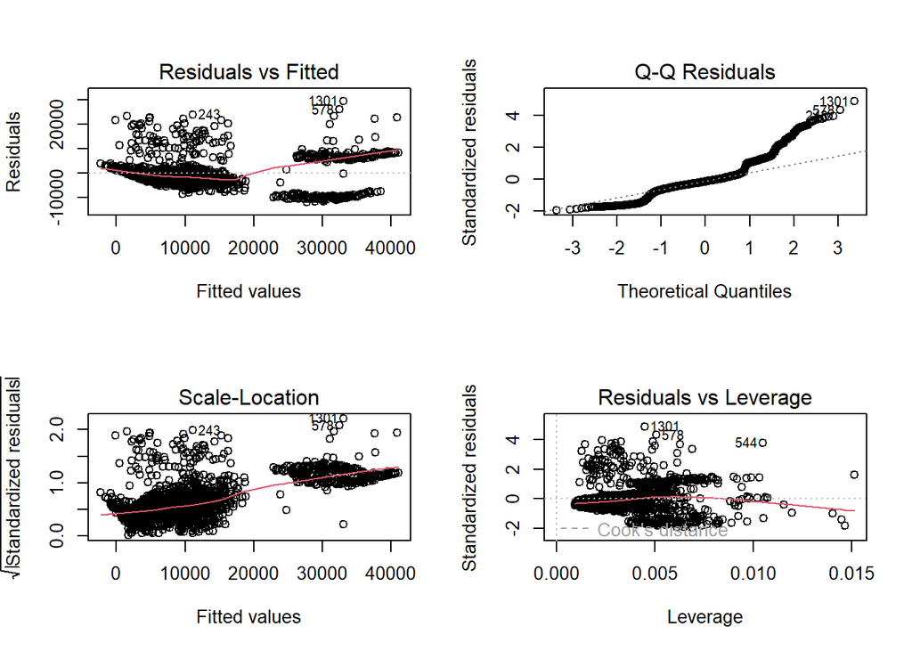

```r
par(mfrow=c(2,2))
plot(m_multi)
```

“Three-Band” Pattern: You can clearly see three distinct, parallel diagonal clusters. This is a “smoking gun” in the insurance dataset. It suggests that the model is failing to capture a major categorical interaction—likely the difference between smokers with high BMIs vs. non-smokers.

Non-Constant Variance: The spread of residuals is not uniform across the horizontal axis (fitted values). This confirms heteroscedasticity, meaning the model’s prediction error increases as the predicted charges increase.

2. Normal Q-Q: Heavy-Tailed Errors

Deviation at the Right Tail: Notice how the points curve sharply upward away from the dashed line on the right side.

3. Scale-Location: Confirming the Variance Issue

Upward Trend: The red line is not horizontal; it has a slight upward slope.

Inference: This further proves that the magnitude of the residuals grows with the fitted values. Mathematically, this violates the OLS assumption of homoscedasticity, which can make your standard errors (and therefore your p-values) unreliable.

4. Residuals vs Leverage: Influential Outliers

By transforming the response variable to $log(charges)$, we shrink the distance between the high-cost outliers and the median, which often collapses those problematic bands into a more random “cloud” of residuals.

```r
m_log <- lm(log(charges) ~ age + bmi + children + smoker, data = df)
summary(m_log)
```

```
##
## Call:
## lm(formula = log(charges) ~ age + bmi + children + smoker, data = df)
##
## Residuals:
##      Min       1Q   Median       3Q      Max
## -1.11340 -0.19883 -0.04688  0.07197  2.07581
##
## Coefficients:
##              Estimate Std. Error t value Pr(>|t|)
## (Intercept) 6.9827766  0.0697227 100.151  < 2e-16 ***
## age         0.0347826  0.0008805  39.502  < 2e-16 ***
## bmi         0.0106096  0.0020264   5.236 1.91e-07 ***
## children    0.1011976  0.0101989   9.922  < 2e-16 ***
## smokeryes   1.5432438  0.0304372  50.703  < 2e-16 ***
## ---
## Signif. codes:  0 '***' 0.001 '**' 0.01 '*' 0.05 '.' 0.1 ' ' 1
##
## Residual standard error: 0.4491 on 1333 degrees of freedom
## Multiple R-squared:  0.7622, Adjusted R-squared:  0.7614
## F-statistic:  1068 on 4 and 1333 DF,  p-value: < 2.2e-16
```

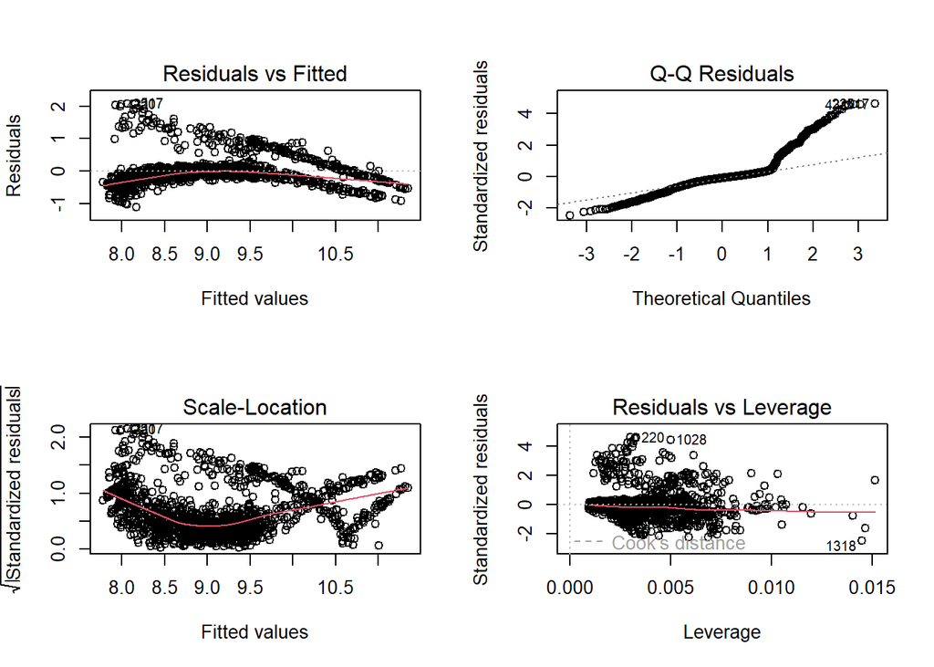

```r
# Re-checking diagnostics
par(mfrow=c(2,2))
plot(m_log)
```

```r
stargazer(m_multi, m_log,
          type = "text",
          column.labels = c("Raw Charges", "Log Charges"),
          digits = 3)
```

```
##
## ============================================================
##                                     Dependent variable:
##                                 ----------------------------
##                                     charges     log(charges)
##                                   Raw Charges   Log Charges
##                                       (1)           (2)
## ------------------------------------------------------------
## age                               257.850***      0.035***
##                                    (11.896)       (0.001)
##
## bmi                               321.851***      0.011***
##                                    (27.378)       (0.002)
##
## children                          473.502***      0.101***
##                                    (137.792)      (0.010)
##
## smokeryes                        23,811.400***    1.543***
##                                    (411.220)      (0.030)
##
## Constant                        -12,102.770***    6.983***
##                                    (941.984)      (0.070)
##
## ------------------------------------------------------------
## Observations                         1,338         1,338
## R2                                   0.750         0.762
## Adjusted R2                          0.749         0.761
## Residual Std. Error (df = 1333)    6,067.787       0.449
## F Statistic (df = 4; 1333)        998.123***    1,067.882***
## ============================================================
## Note:                            *p<0.1; **p<0.05; ***p<0.01
```

#### Inferences from the Log-Model:

Percentage-Based Interpretation: Because the dependent variable is now logged, the coefficients have a new meaning:

Age: A one-year increase in age is associated with an $e^{\beta_{age}} - 1$ percentage increase in charges (usually around 3.5% to 4%).

Smoker: Since this is a dummy variable, the impact is massive; smokers see a percentage increase in charges calculated by $100 \times (e^{\beta_{smoker}} - 1)$.

```r
m_multi <- lm(charges ~ age + bmi + children + smoker, data = df)

# 1. Outliers
std_resid <- rstudent(m_multi)
outliers <- which(abs(std_resid) > 3)

# 2. Leverage Points
hat_vals <- hatvalues(m_multi)
leverage_points <- which(hat_vals > (2 * 5 / nrow(df)))

# 3. Influential Points
cooks_dist <- cooks.distance(m_multi)
influential_points <- which(cooks_dist > (4 / nrow(df)))

# Summary of Findings
list(Outliers = outliers[1:5],
     Leverage = leverage_points[1:5],
     Influential = influential_points[1:5])
```

```
## $Outliers
##   4  35 103 141 220
##   4  35 103 141 220
##
## $Leverage
## 15 33 40 72 84
## 15 33 40 72 84
##
## $Influential
##  4 10 35 59 63
##  4 10 35 59 63
```

The Overlap: Rows 4 and 35

Inference: These are the most dangerous points in your dataset. An outlier that is also influential means it is both a “poor fit” for the model and it has enough “weight” to pull the regression line toward it.

Leverage Points: The “Extreme” Profiles Observations: Rows like 15, 33, 40, 72, 84 are identified as leverage points.

Inference: These individuals have unusual predictor values (X-space) but aren’t necessarily outliers in their charges (Y-space).

Influential Points: The “Line Pullers”

Observations: Rows 4, 10, 35, 59, 63 have high Cook’s Distance.

Inference: These points are single-handedly changing your $\beta$ coefficients.

```r
m_log <- lm(log(charges) ~ age + bmi + children + smoker, data = df)

std_resid_log <- rstudent(m_log)
outliers_log <- which(abs(std_resid_log) > 3)

hat_vals_log <- hatvalues(m_log)
leverage_log <- which(hat_vals_log > (2 * 5 / nrow(df)))

cooks_dist_log <- cooks.distance(m_log)
influential_log <- which(cooks_dist_log > (4 / nrow(df)))

list(Outliers_Log = outliers_log,
     Leverage_Log = leverage_log,
     Influential_Log = influential_log)
```

```
## $Outliers_Log
##    4  103  141  220  292  307  322  341  355  398  431  469  517  526  527  555
##    4  103  141  220  292  307  322  341  355  398  431  469  517  526  527  555
##  807  859  937  984 1009 1020 1028 1040 1081 1124 1135 1158 1190 1196 1216 1329
##  807  859  937  984 1009 1020 1028 1040 1081 1124 1135 1158 1190 1196 1216 1329
##
## $Leverage_Log
##   15   33   40   72   84   99  117  129  167  186  251  266  282  293  302  345
##   15   33   40   72   84   99  117  129  167  186  251  266  282  293  302  345
##  381  413  414  426  439  495  544  550  569  622  641  661  665  675  804  848
##  381  413  414  426  439  495  544  550  569  622  641  661  665  675  804  848
##  861  878  902  933  938  970  985  995 1048 1086 1117 1125 1131 1157 1187 1246
##  861  878  902  933  938  970  985  995 1048 1086 1117 1125 1131 1157 1187 1246
## 1266 1273 1308 1318
## 1266 1273 1308 1318
```

[output cut: 16 more lines]

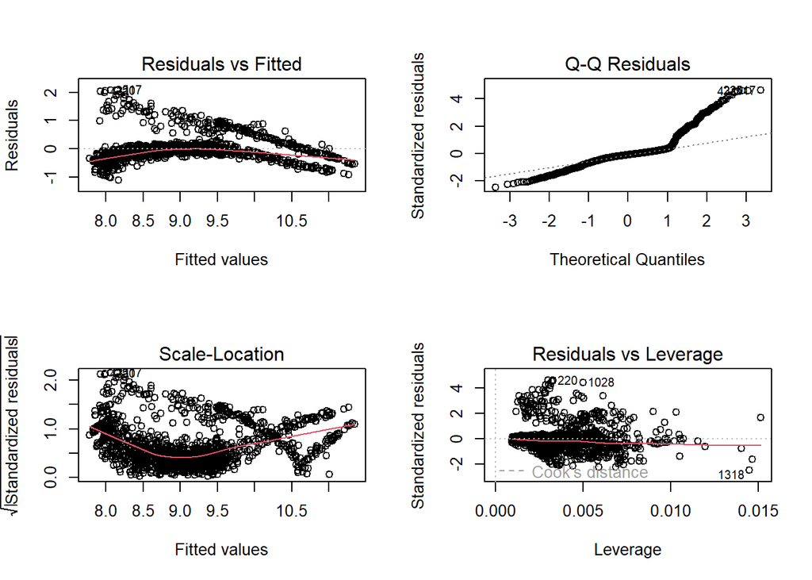

```r
par(mfrow=c(2,2))
plot(m_log)
```

Exploding Influence (Cook’s Distance) Observations: The Influential_Log list has grown significantly.

Inference: On the log scale, even small errors in predicting low-cost individuals can lead to a high Cook’s Distance. The model is now much more “democratic”—it cares about fitting every point accurately, rather than just chasing the big-money smokers.

Let’s proceed with the Stepwise Selection using all variables on this m_log model. This will tell us if sex or region (which we haven’t used much yet) are actually useful once the cost scale is normalized.

```r
m_full_log <- lm(log(charges) ~., data = df)

# Applying Stepwise Selection
final_step_model <- step(m_full_log, direction = "both")
```

```
## Start:  AIC=-2162.05
## log(charges) ~ age + sex + bmi + children + smoker + region +
##     bmi_centered
##
##
## Step:  AIC=-2162.05
## log(charges) ~ age + sex + bmi + children + smoker + region
##
##            Df Sum of Sq    RSS      AIC
## <none>                  262.33 -2162.05
## - sex       1      1.89 264.21 -2154.46
## - region    3      4.68 267.01 -2144.38
## - bmi       1      8.04 270.37 -2123.67
## - children  1     20.08 282.41 -2065.37
## - age       1    310.40 572.73 -1119.31
## - smoker    1    520.12 782.45  -701.83
```

```r
summary(final_step_model)
```

```
##
## Call:
## lm(formula = log(charges) ~ age + sex + bmi + children + smoker +
##     region, data = df)
##
## Residuals:
##      Min       1Q   Median       3Q      Max
## -1.07186 -0.19835 -0.04917  0.06598  2.16636
##
## Coefficients:
##                   Estimate Std. Error t value Pr(>|t|)
## (Intercept)      7.0305581  0.0723960  97.112  < 2e-16 ***
## age              0.0345816  0.0008721  39.655  < 2e-16 ***
## sexmale         -0.0754164  0.0244012  -3.091 0.002038 **
## bmi              0.0133748  0.0020960   6.381 2.42e-10 ***
## children         0.1018568  0.0100995  10.085  < 2e-16 ***
## smokeryes        1.5543228  0.0302795  51.333  < 2e-16 ***
## regionnorthwest -0.0637876  0.0349057  -1.827 0.067860 .
## regionsoutheast -0.1571967  0.0350828  -4.481 8.08e-06 ***
## regionsouthwest -0.1289522  0.0350271  -3.681 0.000241 ***
## ---
## Signif. codes:  0 '***' 0.001 '**' 0.01 '*' 0.05 '.' 0.1 ' ' 1
##
## Residual standard error: 0.4443 on 1329 degrees of freedom
## Multiple R-squared:  0.7679, Adjusted R-squared:  0.7666
## F-statistic: 549.8 on 8 and 1329 DF,  p-value: < 2.2e-16
```

```r
set.seed(123)
index <- sample(1:nrow(df), 0.8 * nrow(df))
train <- df[index, ]
test <- df[-index, ]

m_raw <- lm(charges ~ age + sex + bmi + children + smoker + region, data = train)
m_log_final <- lm(log(charges) ~ age + sex + bmi + children + smoker + region, data = train)

pred_raw <- predict(m_raw, newdata = test)
pred_log <- exp(predict(m_log_final, newdata = test))

rmse_raw <- sqrt(mean((test$charges - pred_raw)^2))
rmse_log <- sqrt(mean((test$charges - pred_log)^2))

cat("RMSE for Raw Model: ", rmse_raw, "\n")
```

```
## RMSE for Raw Model:  5763.385
```

```r
cat("RMSE for Log-Stepwise Model: ", rmse_log, "\n")
```

```
## RMSE for Log-Stepwise Model:  7767.321
```

### Summary :

Interpretability and Real-World Fit: Shifting to a log-scale allowed for a percentage-based interpretation (e.g., a 3.5% increase per year of age), which better reflects the compounding nature of insurance risk compared to a flat dollar-amount increase.

Inference :